# overviewPresentation slides

[figure not shown]

### Tradinator

A sophisticated Machine Learning Algoritmic Trading Bot, sent back through time to help crypto humans successfully trade.

## Overview

The Tradinator is a free and open-source crypto trading bot written in Python that uses machine learning models to predict profitable cryptocurrency trades. It is currently designed to support exchanges like Kraken and Coinspot and is controlled via AWS Lex and integrated into our Slack channel.

The tradinator gathers live data on a select number of cryptocurrencies and compares the data with results produced through Machine Learning models to predict the Buy and Sell signals.

Trades will then be automatically placed by the Tradintor using these recommendations on a Kraken exchange account every hour.

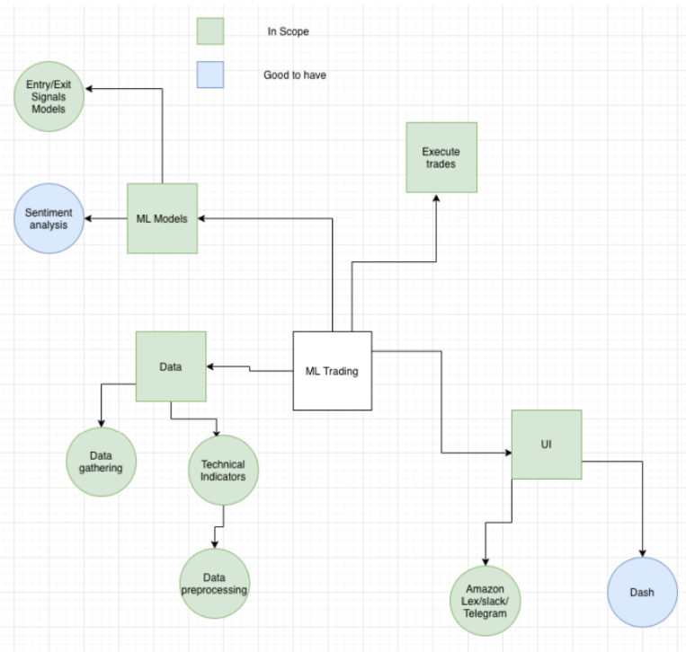

### Libraries

The tradinator uses a variety of ready-made python and machine learning libraries. These libraries include:

- Pandas - Used to manipulate the price data into workable DataFrames
- CCXT - A crypto-specific library used to connect and trade with cryptocurrency exchanges.
- Finance - We used this library to download historical market data.
- Tensorflow - A library used to build and train Neural Network models.
- Keras - This API is built on top of Tensorflow.
- Scikit Learning - A library used to build and train Machine Learning models.
- Matplotlib - A python library used to render static, animated and interactive graphs.
- TA-Lib - This library performs technical analysis on our chosen cryptocurrencies.

### Technical Indicators

The Tradinator uses techinical analysis indicators to identify Buy or Sell signals. These signals are also backtested against historical data. Technical indicators are:

#### Momentum

- SMA - (Simple Moving Average)
- RSI - (Relative Strength Index)
- CCI - (Commodity Channel Index)
- MACD - (Moving Average Convergence Divergence)

#### Trend Strength

- ADX - (Average Directional Movment Index)

#### Volatility

- ATR - (Average True Range)
- BB - (Bollinger Bands)

#### Volume

- SMA (Simple Moving Average- For Volume)

### Machine Learning Models

- Suport Vector
- Decision Tree
- Logical Regression
- Random Forrest
- Gradient Boost
- Adaptive Boosting
- LSTM RNN

Out of of all models the best results came from from Adaptive Boost.

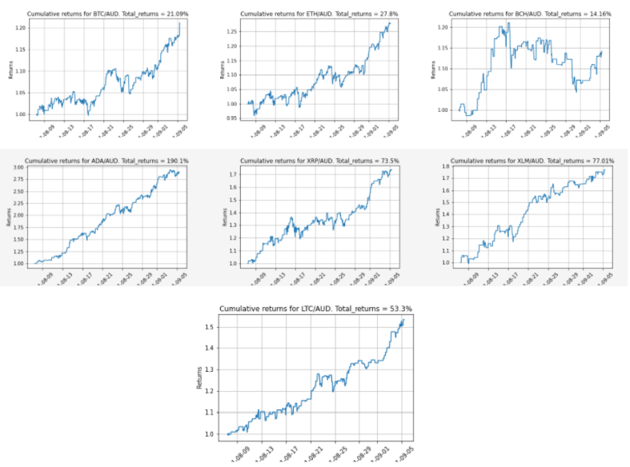

### Predictions and Trading

- Uploaded the Joblib file to AWS S3 Bucket
- Created a script that runs in the first minute of every hour and does the follow:
- Get the Joblib file from S3
- Asyncronsely creates tasks for each coin the Tradinator supports
- Generates predictions for the coin
- Executes the latest signal generated for the coin
- Saves the generated prediction to a .csv file and uploads that to the S3 bucket

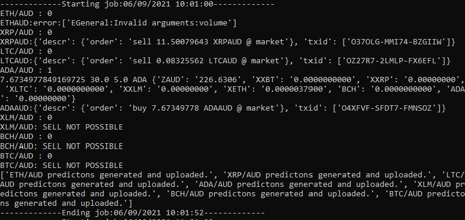

### AWS Lex Bot

The Lex bot allows the user to interact with the Tradinator to get recommendation and place buy orders on the Kracken Exchance through a messaging platform called Slack.

(Demo)

### Where To From Here

Given the short window of time we were given to complete a Minimal Viable Product we did not complete all the features. Here are a few that we left out.

- Portfolio Management
- User Dashboard
- Ability to link excange to view profit or loss from dashboard
- Add more exchanges
- One line install